# Noah Miller GitHub Python Project 4: Intro to Deep Neural Networks using GPU

In this notebook, I will be using Tensorflow, Keras, and my RTX 2060 Super to build a couple of deep neural networks to classify images. The model I will build will be to classify how many fingers a picture of a hand is holding up. This moodel will be trained on a Graphics Processing Unit (GPU) which, due to its thousands of CUDA cores, make it excellent for parallel operations. These cores make GPUs excellent for training neural networks.

The data source for the fingers data set comes from https://www.kaggle.com/datasets/koryakinp/fingers.

## Part 1: Importing Packages and Data

First, let's import the necessary packahes and data we will be using. First, I will be surpressing warnings just for the sake of keeping this notebook clean. From there I am also importing Tensorflow and Keras, which will be the library on top of which we build our deep neural networks. We will use NumPy for transforming images into arrays and OS and Glob to tell Python where to search for these images. PIL enables us to read in images and apply some necessary transformations. RE is used for string manipulations. We are importing the shuffle method from random so that our list of images is read in a random order. This prevents us from needing to randomly shuffle after the data has been read in; the shuffling happens before. Finally, I'm using backend from Keras to help free GPU memory.

```python
import tensorflow as tf  # Base package for deep learning
from tensorflow import keras  # Keras makes building deep neural networks easy
import numpy as np  # For some numerical calculations
import os  # For interactions with the operating system
os.environ['TF_CPP_MIN_LOG_LEVEL'] = '3'  # Surpesses warnings
from PIL import Image  # Makes working with images in Python much easier
import glob  # Useful here for recursively searching through folders in a directory
import re  # Regular expression; great for working with strings
from random import shuffle  # Randomly shuffles list of images
from keras import backend as K  # For working with GPU memory
%matplotlib inline
import matplotlib.pyplot as plt  # For creating visualizations
import seaborn as sns  # For creating visualizations
from mpl_toolkits.axes_grid1 import ImageGrid  # Allows images to be portrayed as a grid
import random
random.seed(123)  # Sets random seed for reading in data
tf.random.set_seed(123)  # Sets random seed for Tensorflow operations
from sklearn.metrics import confusion_matrix  # For creating a confusion matrix
import pandas as pd  # Aids in creating confusion matrix
```

With these packages imported, let's also make sure our GPU is available.

```python
print("GPUs: ", len(tf.config.experimental.list_physical_devices('GPU')))
```

```
GPUs:  1
```

Python and Tensorflow do not print this out here, but I am using an NVidia RTX 2060 Super for this task. It has 8 gigabytes of VRAM and 2,176 CUDA cores.

I am running this notebook on Ubuntu 22.04, which allows me to call the command line inside of a Jupyter Notebook. Let's get a base idea for how much memory our GPU is currently consuming, as well as other useful information.

```python
!nvidia-smi
```

```
Mon Jun 20 19:23:42 2022
+-----------------------------------------------------------------------------+
| NVIDIA-SMI 510.60.02    Driver Version: 510.60.02    CUDA Version: 11.6     |
|-------------------------------+----------------------+----------------------+
| GPU  Name        Persistence-M| Bus-Id        Disp.A | Volatile Uncorr. ECC |
| Fan  Temp  Perf  Pwr:Usage/Cap|         Memory-Usage | GPU-Util  Compute M. |
|                               |                      |               MIG M. |
|===============================+======================+======================|
|   0  NVIDIA GeForce ...  Off  | 00000000:08:00.0  On |                  N/A |
| 41%   43C    P0    40W / 175W |    450MiB /  8192MiB |      1%      Default |
|                               |                      |                  N/A |
+-------------------------------+----------------------+----------------------+

+-----------------------------------------------------------------------------+
| Processes:                                                                  |
|  GPU   GI   CI        PID   Type   Process name                  GPU Memory |
|        ID   ID                                                   Usage      |
|=============================================================================|
|    0   N/A  N/A      1987      G   /usr/lib/xorg/Xorg                185MiB |
|    0   N/A  N/A      2164      G   ...ome-remote-desktop-daemon        1MiB |
|    0   N/A  N/A      2201      G   /usr/bin/gnome-shell               98MiB |
|    0   N/A  N/A      5389      G   ...3/usr/lib/firefox/firefox      120MiB |
+-----------------------------------------------------------------------------+
```

Since I am using the same GPU to run the display in this instance, it's going to use more memory and power than one might find on a similar GPU used in a server setting, for example. Nonetheless, this will be enough memory available for us to train our neural nets just fine.

Now, let's import our data. Although the data comes from the source split into testing and training folders, I want to mix these up to ensure there exists no bias between the two. All of the pictures will be read in at once, but the order in which they are read is randomly shuffled.

```python
def images_import(parent_folder):
    x_data = []  # This is where the numpy arrays will be stored
    y_data = []  # This is where the labels will be stored
    image_files = glob.glob(parent_folder + "/**/*.png", recursive = True)  # Opens all sub-files (train and test folders)
    shuffle(image_files)  # For testing, we can randomly shuffle not and split later
    for imag in image_files:  # imag represents the file name
        img = Image.open(imag).convert('L').resize((128, 128), Image.ANTIALIAS)
        # convert('L') means to apply grayscale, resize(128,128) means to make the image 128 by 128 pixels
        img = np.array(img)  # Converts the image into a NumPy array
        x_data.append(img)  # Appends this new array into our list of observations
        # Now I'm identifying labels according to the file name. This involves parsing some strings
        label = int(re.findall(r'\d+',imag[-7:])[0])  # Explanation below
        # These files are labelled according to which hand (left or right) and how many fingers are held up.
        # I am only interested in the number, so the label pulls from the file name according to the number of fingers
        # These numbers are found in the last 7 characters of the file name's string
        y_data.append(label)  # Appends label (number of fingers) to target list

    return np.array(x_data), np.array(y_data)  # These must be returned as NumPy arrays


x_data, y_data = images_import('/home/noah/Downloads/fingers')  # This is the directory which contrains our images
x_data = x_data/255  # Normalizes pizels according to shading
```

Next, let's get an idea of the images we're working with. The cell below displays our images in a grid along with their proper labels. Although we applied grayscale to the images, they are reporting colors because of their luminance.

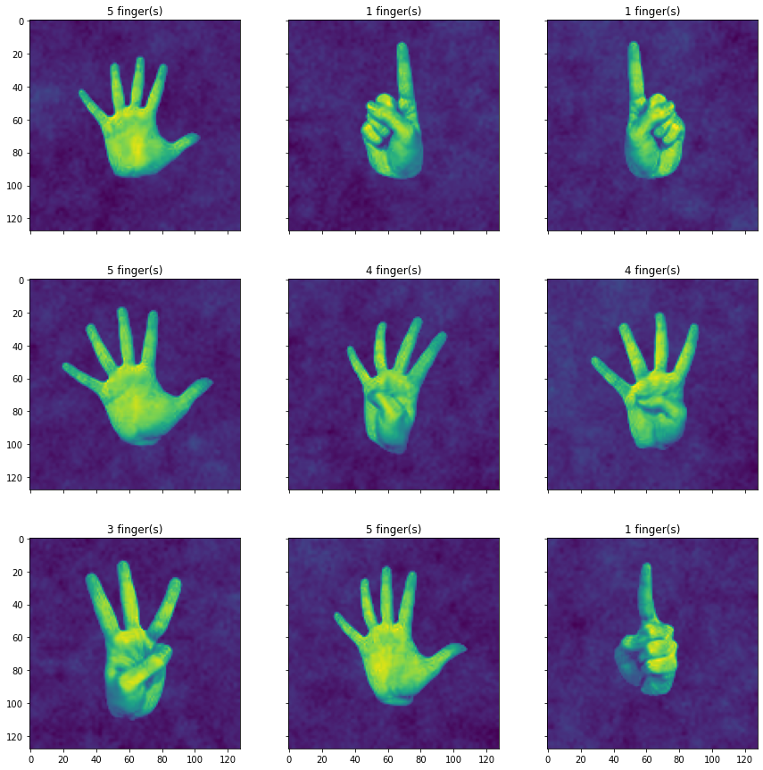

```python
fig = plt.figure(figsize=(15, 15))
grid = ImageGrid(fig, 111,
                 nrows_ncols=(3, 3),
                 axes_pad=0.75)

count = 0
for ax, im in zip(grid, x_data):
    ax.imshow(im)
    ax.set_title(f"{y_data[count]} finger(s)")
    count += 1

plt.show()
```

## Part 2: Preparing Data for Model

Now let's see the size of our data before a testing and training split.

```python
x_data.shape[0]  # Returns number of images in x_data
```

```
21600
```

Our data consists of 21,600 samples. This makes sense since it is the sum of the number of samples in the original source's training set (18,000) and the number of samples in the testing set (3,600).

For training and testing, I prefer to split my data roughly according to a 75/25 split. This would mean that 16,200 samples would exist in our training set and 5,400 samples would exist in our testing set, which is a significant split from the original dataset's split. The code below will automatically split according to our desired ratio.

```python
x_train = x_data[0:int(x_data.shape[0]*.75)]
y_train = y_data[0:int(y_data.shape[0]*.75)]
x_test = x_data[int(x_data.shape[0]*.75): int(x_data.shape[0])]
y_test = y_data[int(x_data.shape[0]*.75):int(x_data.shape[0])]
```

Next, we need to let Keras know these are categorical variables since we're essentially classifying the hands into different groups depending on how many fingers are held up. There are six categories since this includes any amount of fingers being held up from 1 to 5 as well as cases in which no fingers are held up.

```python
y_train_keras = keras.utils.to_categorical(y_train, num_classes = 6)
y_test_keras = keras.utils.to_categorical(y_test, num_classes = 6)
```

## Part 3: Defining the Model

Finally, before we can train the model, we need to define the model. This model is extremely simple; it contains only an input later with a shape of 128 by 128 (matching the dimensions of our images) and an output later with 6 neurons, matching the number of classes for which we want to predict. We are using stochastic gradient descent for our optimizer, a powerful tool which works to minimize errors while training by randomly iterating through parameters which minimize our loss function.

```python
def get_model():
    model = keras.Sequential([
    keras.layers.Flatten(input_shape=(128,128,1)),  # Input layer
    keras.layers.Dense(6, activation='sigmoid')  # Output layer
    ])

    model.compile(optimizer='SGD',
                  loss='categorical_crossentropy',
                  metrics=['accuracy'])
    return model
```

## Part 4: Training Model

Finally, we may begin to train our model. Using the context manager, we can specify which device we want to train our model on. Here, I'm essentially choosing the first GPU available. This can be changed to "with tf.device('/CPU:0'):" for those who with to run on CPUs instead. In the future, I would like to see what it is like to train on multiple GPUs at once as well.

```python
with tf.device('/GPU:0'):  # Telling tensorflow which device (GPU vs CPU) to use
    model_gpu = get_model()  # Defining the model to use
    model_gpu.fit(x_train, y_train_keras, epochs = 5)  # Training model for 10 epochs
    score, accuracy = model_gpu.evaluate(x_test, y_test_keras)  # Seeing how we performed; mostly using accuracy
    K.clear_session()
    print(f"Model accuracy on testing data: {accuracy}")  # Prints accuracy
    predictions = model_gpu.predict(x_test)
```

```
Model accuracy on testing data: 0.9974074363708496
```

I chose to train this model on 5 epochs in order to not overfit. Likewise, this data is relatively simple as far as images are concerned, so training should not take too long anyway. We can see this model converged extremely fast and its accuracy score was nearly perfect on data it had not seen before!

## Part 5: Validating Model

Let's look at some test images along with their predictions.

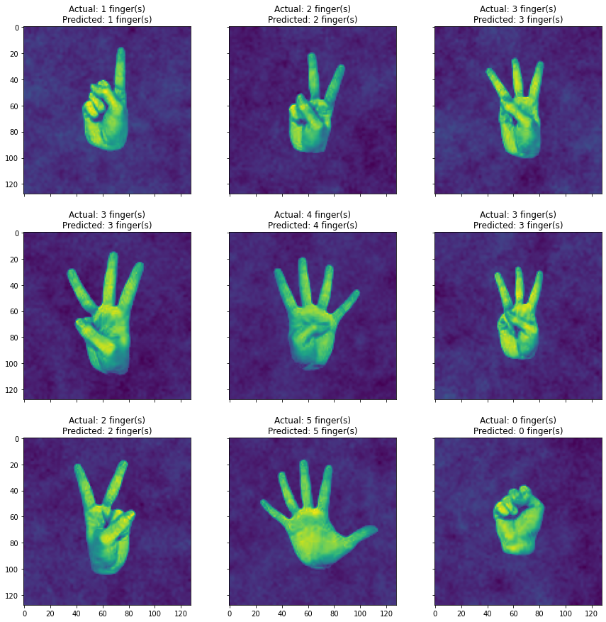

```python
fig = plt.figure(figsize=(15, 15))  # How large to make each image
grid = ImageGrid(fig, 111,
                 nrows_ncols=(3, 3),
                 axes_pad=0.75)  # Defines how large of space to make between images

classes = np.argmax(predictions, axis = 1)  # Creates classification based on most confident class

count = 0
for ax, im in zip(grid, x_test):
    ax.imshow(im)
    ax.set_title(f"Actual: {y_test[count]} finger(s)\nPredicted: {classes[count]} finger(s)")
    count += 1

plt.show()
```

Amazing! It looks like all of the predictions in this example printed above turned out correctly. I am, however, interested to see which ones get got incorrect. Now let's take a look at a confusion matrix to see which classifications we got correctly and which ones we predicted incorrectly.

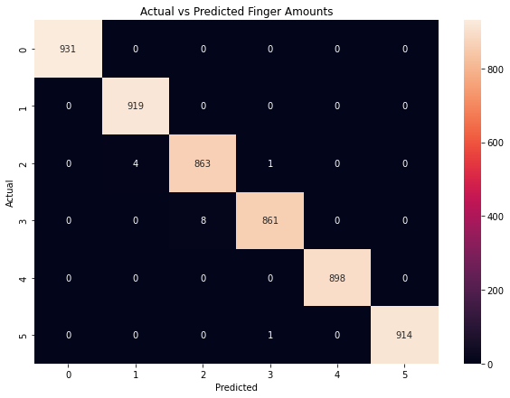

```python
cm = confusion_matrix(y_test, classes)
df_cm = pd.DataFrame(cm, index = [0,1,2,3,4,5],
                  columns = [0,1,2,3,4,5])
plt.figure(figsize = (10,7))
sns.heatmap(df_cm,annot=True,fmt='d')
plt.xlabel("Predicted")
plt.ylabel("Actual")
plt.title("Actual vs Predicted Finger Amounts")

plt.show()
```

Incredible - out of the 5,400 images in our testing set, we only incorrectly predicted 14 of them. Let's identify 5 which performed poorly by comparing where the value of y_test does not match the value of the predicted class.

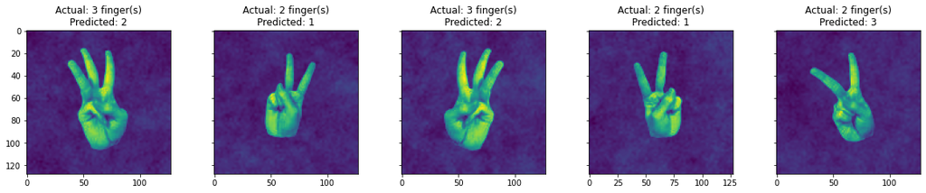

```python
x_test_incorrect = []
y_test_incorrect = []
class_predictions_incorrect = []
for imag in range(len(y_test)):
    if y_test[imag] != classes[imag]:
        x_test_incorrect.append(x_test[imag])
        y_test_incorrect.append(y_test[imag])
        class_predictions_incorrect.append(classes[imag])

fig = plt.figure(figsize=(20, 20))
grid = ImageGrid(fig, 111,
                 nrows_ncols=(1, 5),
                 axes_pad=0.75)

x_test_incorrect = np.array(x_test_incorrect)
y_test_incorrect = np.array(y_test_incorrect)
class_predictions_incorrect = np.array(class_predictions_incorrect)

count = 0
for ax, im in zip(grid, x_test_incorrect):
    ax.imshow(im)
    ax.set_title(f"Actual: {y_test_incorrect[count]} finger(s)\nPredicted: {class_predictions_incorrect[count]}")
    count += 1

plt.show()
```

If some of these images look similar to each other, they are not. The have slightly different shadings or are flipped, intended to introduce more variance into the dataset.

Overall, this was an interesting first look into using an unstructured data type like images for making predictions. I can see this being useful for aiding medical decisions where a doctor might be given images of an x-ray and might want machine assistance to make a prediction or diagnosis. Likewise, I see it being useful for computer vision tasks in general such as automated self-driving, security (like Windows Hello), and perhaps even automated geospatial intelligence gathering. The possibilities really are endless, and this task has really shown me why GPUs are the best tool for these kinds of jobs.